# Data Science CapStone Project_1

Jitender Kumar

June 11, 2016

## Executive Summary and Introduction

The goal of this project is just to display that we gotten used to working with the data and on track to create prediction algorithm. With this we will learn and familiarze oursleves with NLP and text mining.

Data is obtanied from https://d396qusza40orc.cloudfront.net/dsscapstone/dataset/Coursera-SwiftKey.zip

We have accomplished the following tasks

- Obtaining the data and gaining basic info about the data
- Sample creation using binom function
- Pre processing, filtering and tidying data
- Tokenization and ngrams creation
- Exploratory Analysis of words frequency
- Visualization of ngrams and word clouds
- Feedback about analysis

As a part of Capstone project, we have to further develop a word prediction app.

### Loading and Reading data

```r
setwd("D:/Study/Coursera DS/Data Science Project/Assignment")

read_blogs <- readLines("Data/final/en_US/en_US.blogs.txt")
read_news <- readLines("Data/final/en_US/en_US.news.txt")
read_twitter <- readLines("Data/final/en_US/en_US.twitter.txt")
```

### Preliminary Analysis

```r
setwd("D:/Study/Coursera DS/Data Science Project/Assignment")

file_names <- c("en_US Blogs", "en_US News", "en_US Twitter")

file_size <- round(c(file.info("Data/final/en_US/en_US.blogs.txt")$size/1024^2,
    file.info("Data/final/en_US/en_US.news.txt")$size/1024^2, file.info("Data/final/en_US/en_US.twitter.txt")$size/1024^2),
    2)

file_length <- c(length(read_blogs), length(read_news), length(read_twitter))

file_words <- c(length(unlist(strsplit(read_blogs, " "))), length(unlist(strsplit(read_news,
    " "))), length(unlist(strsplit(read_twitter, " "))))

total_char <- c(sum(nchar(read_blogs)), sum(nchar(read_news)), sum(nchar(read_twitter)))

info_table <- as.data.frame(cbind(file_names, file_size, file_length, file_words,
    total_char))

names(info_table) <- c("File Names", "Size (MB)", "Length", "Num words", "Total char")
kable(info_table)
```

| File Names | Size (MB) | Length | Num words | Total char |
| --- | --- | --- | --- | --- |
| en_US Blogs | 200.42 | 899288 | 37334131 | 208361438 |
| en_US News | 196.28 | 77259 | 2643969 | 15683765 |
| en_US Twitter | 159.36 | 2360148 | 30373543 | 162384825 |

### Binom Sampling

Sampling with binom function. Given the huge size of files and memory limitations we are selecting only 2% of original data.

```r
data_blogs <- read_blogs[rbinom(length(read_blogs), size = 1, prob = 0.02) ==
    1]
data_news <- read_blogs[rbinom(length(read_news), size = 1, prob = 0.02) ==
    1]
data_twitter <- read_blogs[rbinom(length(read_twitter), size = 1, prob = 0.02) ==
    1]

## Removing non ASCII characters
data_blogs <- iconv(data_blogs, "UTF-8", "ASCII", "byte")
data_news <- iconv(data_news, "UTF-8", "ASCII", "byte")
data_twitter <- iconv(data_twitter, "UTF-8", "ASCII", "byte")

# Removing large data sets to preserve memory
rm(read_blogs, read_news, read_twitter)
```

### Pre processing data

```r
data_all <- c(data_blogs, data_news, data_twitter)

## Tidying up data
data_all <- gsub(" #\\S*", "", data_all)
data_all <- gsub("(http)(s?)(://)(\\S*)", "", data_all)

rm_words <- c("will", "9b", "9c", "a3", "a9", "b9", "bb", "c2", "c3", "d7",
    "ef", "e1", "e2")

## Profane words list from www.bannedwordlist.com
setwd("D:/Study/Coursera DS/Data Science Project/Assignment")
profane_words <- read.csv("swearWords.txt")
```

We have done the following data transformation

Following transformation will be done as part of dfm function

- Remove Uppercase
- Remove Numbers
- Remove Punctuation
- Remove common english words
- Remove # and @, twitter characters

### Ngrams creation

```r
## Uni gram creation
dfm_unigram <- dfm(data_all, ngrams = 1, removeTwitter = TRUE, stem = TRUE,
    ignoredFeatures = c(rm_words, stopwords("english"), ignoredFeatures = as.character(profane_words)))

## Bi gram creation
dfm_bigram <- dfm(data_all, ngrams = 2, removeTwitter = TRUE, concatenator = " ",
    ignoredFeatures = c(rm_words, stopwords("english"), ignoredFeatures = as.character(profane_words)))

## Tri gram creation
dfm_trigram <- dfm(data_all, ngrams = 3, removeTwitter = TRUE, concatenator = " ",
    ignoredFeatures = c(rm_words, stopwords("english"), ignoredFeatures = as.character(profane_words)))

### Stem = TRUE is giving issues in whitespace, even after cleaning the data.
### Another option is to tokenize and then use dfm.
```

Quanteda’s dfm() and tm_map() function comparision

- dfm is much faster
- we have to use DocumentTermMatrix for cleaning and frequency which can be done very easily with dfm.
- n-grams and token creation is also better

### Word frequency

```r
head(dfm_unigram)
```

```
## Document-feature matrix of: 84,252 documents, 53,538 features.
## (showing first 6 documents and first 6 features)
##        features
## docs    altern argument hear whether re look
##   text1      1        1    1       0  0    0
##   text2      0        0    0       1  1    1
##   text3      0        0    0       0  0    0
##   text4      0        0    0       0  0    0
##   text5      0        0    0       0  0    1
##   text6      0        0    0       0  0    0
```

```r
unigram_freq <- sort(colSums(dfm_unigram), decreasing = T)
bigram_freq <- sort(colSums(dfm_bigram), decreasing = T)
trigram_freq <- sort(colSums(dfm_trigram), decreasing = T)
```

### Word cloud and histograms

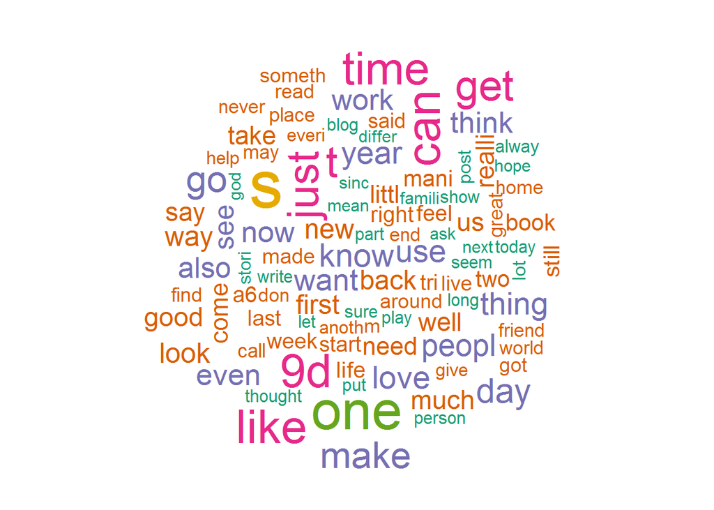

```r
# word cloud of unigrams
plot(dfm_unigram, max.words = 100, colors = brewer.pal(6, "Dark2"))
```

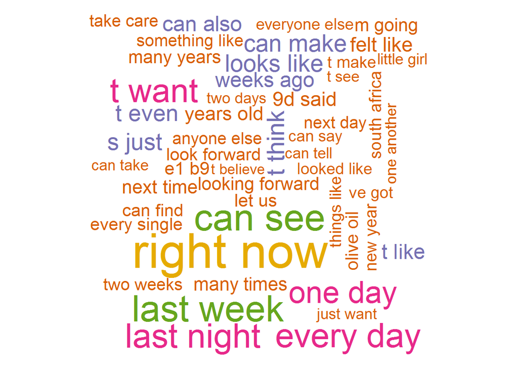

```r
# word cloud of bigrams
plot(dfm_bigram, max.words = 100, colors = brewer.pal(6, "Dark2"))
```

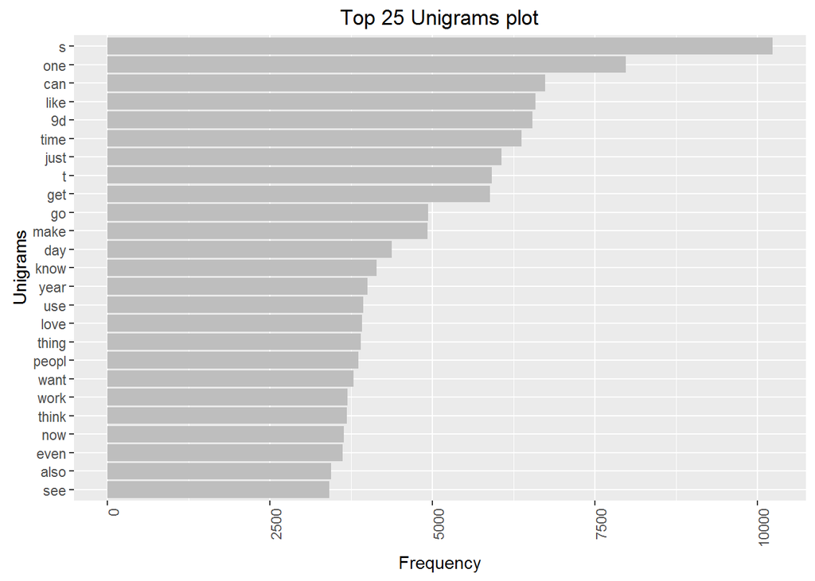

```r
## Unigram histogram
unigram_df <- data.frame(Unigrams = names(unigram_freq), Frequency = unigram_freq)

plot1 <- ggplot(within(unigram_df[1:25, ], Unigrams <- factor(Unigrams, levels = Unigrams)),
    aes(x = reorder(Unigrams, Frequency), y = Frequency))
plot1 <- plot1 + geom_bar(stat = "identity", fill = "grey") + ggtitle("Top 25 Unigrams plot") +
    xlab("Unigrams") + ylab("Frequency")
plot1 <- plot1 + theme(axis.text.x = element_text(angle = 90, hjust = 1)) +
    coord_flip()
plot1
```

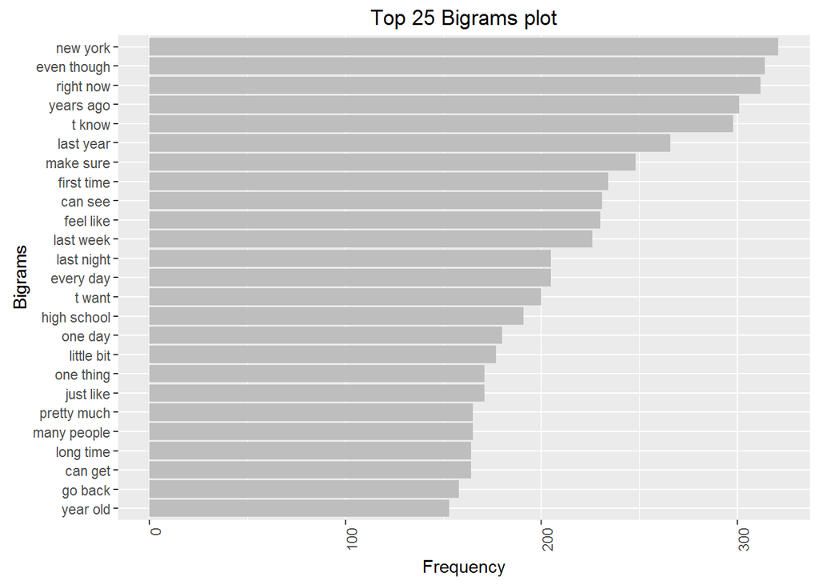

```r
## Bigram histogram
bigram_df <- data.frame(Bigrams = names(bigram_freq), Frequency = bigram_freq)

plot2 <- ggplot(within(bigram_df[1:25, ], Bigrams <- factor(Bigrams)), aes(x = reorder(Bigrams,
    Frequency), y = Frequency))
plot2 <- plot2 + geom_bar(stat = "identity", fill = "grey") + ggtitle("Top 25 Bigrams plot") +
    xlab("Bigrams") + ylab("Frequency")
plot2 <- plot2 + theme(axis.text.x = element_text(angle = 90, hjust = 1)) +
    coord_flip()
plot2
```

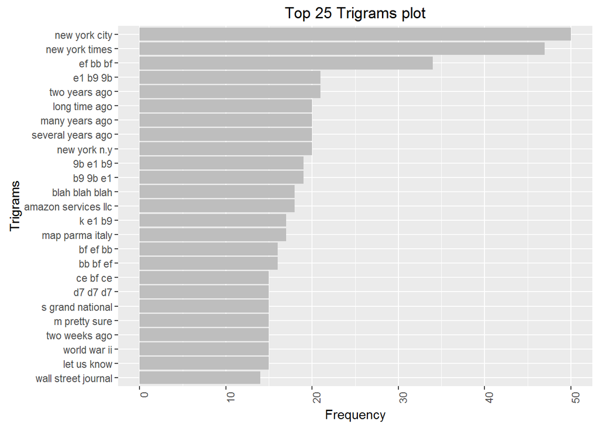

```r
## Trigram histogram
trigram_df <- data.frame(Trigrams = names(trigram_freq), Frequency = trigram_freq)

plot3 <- ggplot(within(trigram_df[1:25, ], Trigrams <- factor(Trigrams, levels = Trigrams)),
    aes(x = reorder(Trigrams, Frequency), y = Frequency))
plot3 <- plot3 + geom_bar(stat = "identity", fill = "grey") + ggtitle("Top 25 Trigrams plot") +
    xlab("Trigrams") + ylab("Frequency")
plot3 <- plot3 + theme(axis.text.x = element_text(angle = 90, hjust = 1)) +
    coord_flip()
plot3
```

From the bi gram, I can see that few most used words are new, last, can and one.

## Conclusion and Next steps

We have demonstrated through the above applicaiton ngrams creation from the sample data.

Going ahead we need to develop an app using the above analysis.

We need to provide probablities of our prediction.Key example is multiple high frequecy bigrams have few common first words.

We also need to explore the following

- explore dfm vs tm functions for text mining
- dealing with mis spelled, missing data
- how to efficiently store the n grams
- ways of smoothing the word prediction probablity
- evaluation and improvment of models

I may have missed many things so let me know your feedback.